# Projet Traitement D'image

## Détection Tumeur : Mélanome

# I_ Manipulation d'histogrammes : Polype

```python
from matplotlib import pyplot as plt
import numpy as np
import cv2
from scipy import signal
import random

path_base = '..//images//'
```

```python
#lecture de l'image
tumeur = cv2.imread(path_base+'1-16.png',0)
```

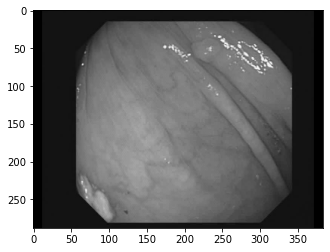

```python
#affichage image
plt.imshow(tumeur,'gray')
```

```python
def histogramme(image,titre):
    plt.hist(image.flatten(),bins= len(image.flatten()),histtype='step')
    plt.title(titre)
```

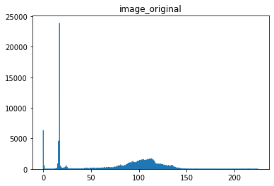

```python
histogramme(tumeur,'image_original')
```

D'après cette histogramme on remarque que l'image original contient enormement de pixels noirs.Ces pixles peuvent fausser le determination du seuil pour le seuillage (pour les étapes suivantes)

# Filtrage

```python
#la creation du masque de convolution pour le filtrage gaussien
Hg = np.array([[1,2,1],[2,4,2], [1,2,1]])/16
```

```python
def filtrGaussien(img):
    #convolution entre la l'image et la matrice H
    B = signal.convolve2d(img, Hg, boundary='fill', mode='same')
    plt.imshow(B,'gray')
```

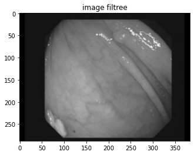

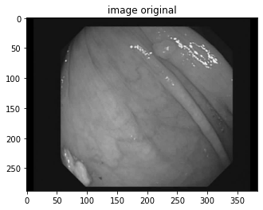

```python
#affichage de l'image filtree
plt.figure()
filtrGaussien(tumeur)
plt.title('image filtree')
plt.figure()
plt.imshow(tumeur,'gray')
plt.title('image original')
```

## Bruitage, filtrage et Détection de contoure

```python
def seuillage(I,seuil=None):
    uint8_I = (255*((I-I.min())/(I.max()-I.min()))).astype(np.uint8)
    return uint8_I>seuil
```

```python
def edgeExtractor(img,methode,seuil=None):

    # Extraction des contours
    contours_img,__ = methode(img)

    # Seuillage des contours
    if seuil is not None:
        thresh_img = seuillage(contours_img,seuil)
    else:
        # Si le seuil n'est pas défini, on va ici faire une binarisation avec seuillage automatique (Otsu)
        uint8_img = (255*((contours_img-contours_img.min())/(contours_img.max()-contours_img.min()))).astype(np.uint8)
        seuil,thresh_img = cv2.threshold(uint8_img,0,255,cv2.THRESH_BINARY+cv2.THRESH_OTSU)
        print("Seuillage Otsu : {}".format(seuil))
    return thresh_img
```

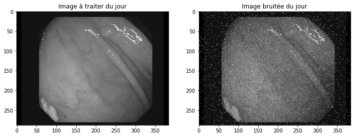

```python
def salt_and_pepper_noise(img,p):
    # Création masque aléatoire avec p% de 0 et (100-p)% de 1
    mask=(np.random.randint(100,size=img.shape)>p)
    # Image bruit avec aléatoirement du blanc et du noir
    new_img = np.random.randint(2,size=img.shape)*255
    # Tous les pixels de mask à 0, prennent la valeur de new_img (0 ou 255) dans l'image originale
    new_img[mask]=img[mask]
    return new_img.astype(np.uint8)

noisy_polype = salt_and_pepper_noise(tumeur,3)

plt.figure()
plt.subplots(2,1,figsize=(12,12))
plt.subplot(121)
plt.imshow(tumeur,'gray')
plt.title('Image à traiter du jour')
plt.subplot(122)
plt.imshow(noisy_polype,'gray')
plt.title('Image bruitée du jour')
plt.show()
```

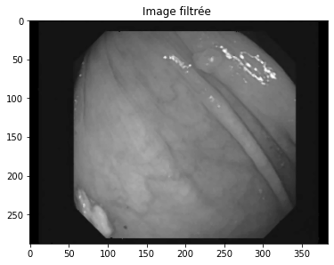

```python
import itertools
from scipy.ndimage.interpolation import shift

def median_filter(img,n):
    return np.floor(np.nanmedian(np.stack([shift(img,(i-n//2,j-n//2),cval=np.NaN) for i,j in itertools.product(range(n),range(n))],axis=-1),axis=(-1))).astype(np.uint8)

preprocess_polype = median_filter(noisy_polype,3)

plt.figure()
plt.subplots(1,1,figsize=(6,6))
plt.imshow(preprocess_polype,'gray')
plt.title('Image filtrée ')
```

```python
def Laplacien(I):
    Laplacien=np.array([[0,-1,0],[-1,4,-1],[0,-1,0]],dtype=np.float64)
    Lap_I=cv2.filter2D(I,-1,Laplacien)
    norme_I = np.linalg.norm([Lap_I],axis=0)
    return norme_I,Lap_I
```

```
Seuillage Otsu : 35.0
```

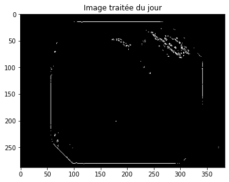

```python
edge_polype = edgeExtractor(preprocess_polype,Laplacien)

plt.figure()
plt.subplots(1,1,figsize=(6,6))
plt.imshow(edge_polype,'gray')
plt.title('Image traitée du jour')
```

```python
imgg = tumeur[:,100:300]
imgg[imgg<100]= 0
imgg[imgg>120] = 0
```

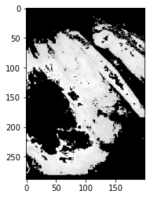

```python
plt.imshow(imgg,'gray')
```

```python
def histogramme(image,titre):
    plt.hist(image.flatten(),bins= len(image.flatten()),histtype='step')
    plt.title(titre)
```

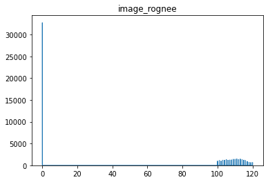

```python
histogramme(imgg,'image_rognee')
```

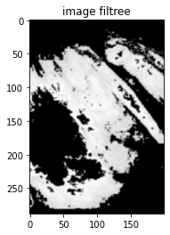

```python
plt.figure()
filtrGaussien(imgg)
plt.title('image filtree')
```

```python
ret2,th2 = cv2.threshold(imgg,100,150,cv2.THRESH_BINARY+cv2.THRESH_OTSU)
```

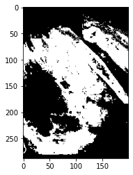

```python
plt.imshow(th2,'gray')
```

Nous avons tout d'abord travailler avec l'image pour localisation d'un polype,mais malheureusement nous n'avons pas reussi à localiser le petit tumeur.Avant d'utiliser les méthode de la segmentation, nous avons rognee l'image pour eliminer tous les pixels noirs entourer l'image et puis nous avons filterer pour enlever tout le bruit existe.et après nous avons utiliser plusieurs méthode pour la segmentation: seuillage avec Otsu et Binarisation d'image qui consiste à affecter un niveau uniforme au pixels pertinents et d´éliminer les autres. à notre avis, le tumeur es trés petit et il a les meme veleurs pixels que d'autre partie de l'image, ce qui implique la difficuté de le detecter.

# Segmentation et Localisation de tumeur

```python
def histogramme(image,titre):
    plt.hist(image.flatten(),bins= len(image.flatten()),histtype='step')
    plt.title(titre)
```

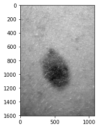

```python
#Telechargement de l'image
Melanome = cv2.imread(path_base+'D36_2_orig.jpg',0)
plt.imshow(Melanome,'gray')
```

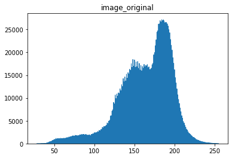

```python
histogramme(Melanome,'image_original')
```

```python
def convolution_faster(img,h):
    h_rows,h_cols=h.shape
    h = h.reshape((-1,))
    rows,cols = img.shape
    large_img = np.stack([shift(img.astype(np.float32),(i-h_rows//2,j-h_cols//2),cval=np.NaN) for i,j in itertools.product(range(h_rows),range(h_cols))],axis=-1)
    return np.dot(large_img,h).astype(np.uint8)
```

```python
expo_h = np.array([[1,1,3,1,1],
                  [1,3,7,3,1],
                  [3,7,16,7,3],
                  [1,3,7,3,1],
                  [1,1,3,1,1]],dtype=np.float64)/80
```

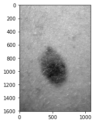

```python
#le filtrage exponentiel
Melanome_expo = convolution_faster(Melanome,expo_h)

plt.imshow(Melanome,'gray')
```

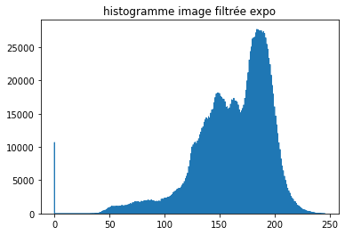

```python
histogramme(Melanome_expo,"histogramme image filtrée expo")
```

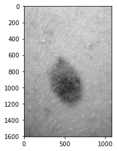

```python
#le filtrage gaussien
gauss_h = np.array([[1,2,1],[2,4,2],[1,2,1]],dtype=np.float64)/16

Melanome_fg = convolution_faster(Melanome,gauss_h)

plt.imshow(Melanome_fg,'gray')
```

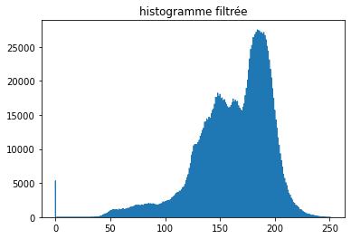

```python
histogramme(Melanome_fg,"histogramme filtrée")
```

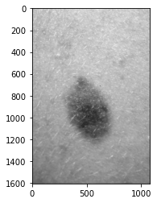

```python
#le filtrage moyenneur
def mean_filter_fast(img,n):
    return np.floor(sum([shift(img.astype(np.float32),(i-n//2,j-n//2),cval=np.NaN) for i,j in itertools.product(range(n),range(n))])/(n*n)).astype(np.uint8)

Melanome_moyenne = mean_filter_fast(Melanome,3)

plt.imshow(Melanome_moyenne,'gray')
```

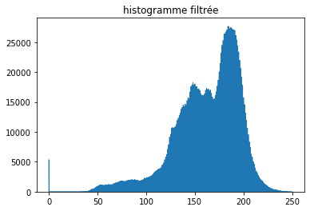

```python
histogramme(Melanome_moyenne,"histogramme filtrée")
```

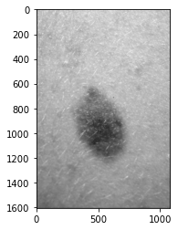

```python
def median_filter(img,n):
    return np.floor(np.nanmedian(np.stack([shift(img,(i-n//2,j-n//2),cval=np.NaN) for i,j in itertools.product(range(n),range(n))],axis=-1),axis=(-1))).astype(np.uint8)

Melanome_median = mean_filter_fast(Melanome,3)

plt.imshow(Melanome_median,'gray')
```

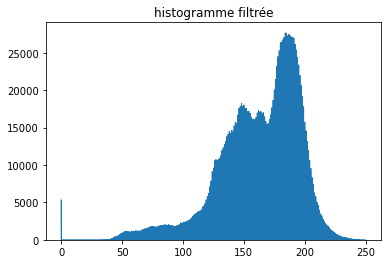

```python
histogramme(Melanome_median,"histogramme filtrée")
```

On constate que l'image n'est pas bruitée alors on commence le traitement

**Méthode de seuillage**

```python
a = 0
b = 120
```

```python
def t2(img,a,b):
    img2 = np.copy(img)
    img2[img<a]=255
    img2[img>b]=255
    return img2
```

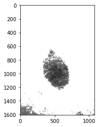

```python
res= t2(Melanome,a,b)
plt.imshow(res,'gray',vmin=0,vmax=255)
```

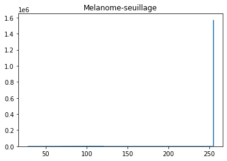

```python
plt.figure(1)
histogramme(res,'Melanome-seuillage')
plt.figure(2)
histogramme(Melanome,'Melanome')
```

```python
def seuillage(I,seuil=None):
    uint8_I = (255*((I-I.min())/(I.max()-I.min())))
    return uint8_I>seuil
```

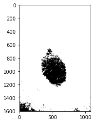

```python
seuilM = seuillage(Melanome,100)
plt.imshow(seuilM,'gray')
```

**Utilisation d'Otsu**

```python
th1,th2= cv2.threshold(Melanome,90,100,cv2.THRESH_OTSU)
```

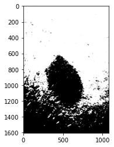

```python
plt.imshow(th2,'gray')
```

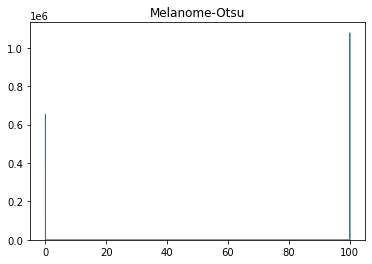

```python
#Histogramme associer
plt.figure(1)
histogramme(th2,'Melanome-Otsu')
plt.figure(2)
histogramme(Melanome,'Melanome')
```

**Tresh Binary**

```python
thresh,imgbin=cv2.threshold(Melanome,120,255,cv2.THRESH_BINARY);
```

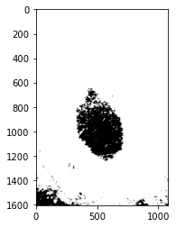

```python
plt.imshow(imgbin,'gray')
```

Histogramme associer à l'image après binarisation

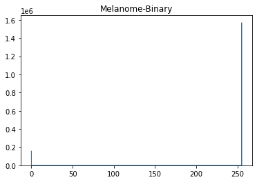

```python
plt.figure(1)
histogramme(imgbin,'Melanome-Binary')
plt.figure(2)
histogramme(Melanome,'Melanome')
```

```python
def binarisation(img,a):
    return 255*(img<a)
```

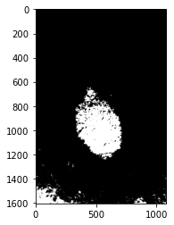

```python
a = 120
Melanome_bi = binarisation(Melanome,a)
plt.imshow(Melanome_bi,'gray')
```

Maintenant nous allons passer au bruitage

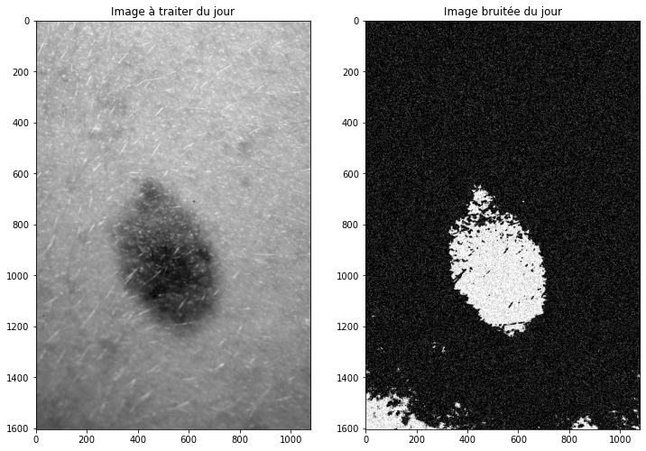

```python
#Bruitage
noisy_Melanome = salt_and_pepper_noise(Melanome_bi,15)

plt.figure()
plt.subplots(2,1,figsize=(12,12))
plt.subplot(121)
plt.imshow(Melanome,'gray')
plt.title('Image à traiter du jour')
plt.subplot(122)
plt.imshow(noisy_Melanome,'gray')
plt.title('Image bruitée du jour')
plt.show()
```

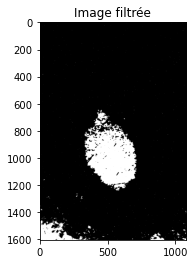

```python
#Fitrage
Melanome_filtre = median_filter(noisy_Melanome,3)

plt.figure()
plt.imshow(Melanome_filtre,'gray')
plt.title('Image filtrée')
```